# Project 1 Obesity Prevalence

Author

Shihong

# 1 Introduction

Obesity is a significant public health concern that affects morbidity and mortality. Monitoring its prevalence is essential for evaluating public health policies and interventions. The Scottish Health Survey, which samples individuals from private households across Scotland, provides an opportunity to study trends in obesity. The primary goal of this analysis is to determine whether there has been a statistically noticeable change in obesity prevalence in Scotland over the period 2008–2012.

# 2 Exploratory Analysis

The prevalence of obesity for each year was computed using the formula:

$$\text{Prevalence (in \%)} = \frac{N_{\text{obese}}}{N_{\text{total}}} \times 100$$

First we will produce a line plot with data points to illustrate the trend in obesity prevalence over the years.

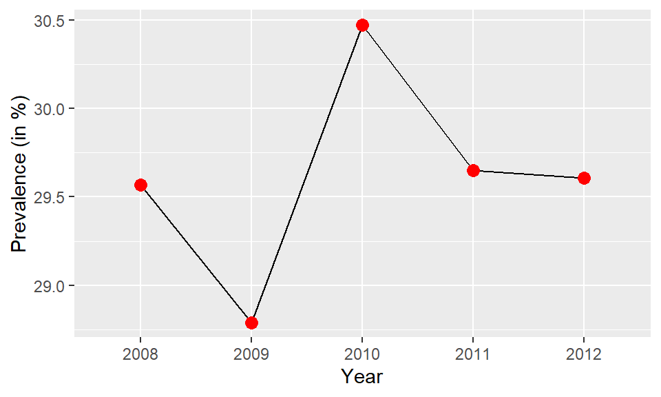

Figure 1: Obesity Prevalence Over Time in Scotland

From the graph we can see that the prevalence appears to fluctuate year to year, rather than moving in a strictly upward or downward path. This suggests that obesity rates may have been influenced by a range of factors that vary from year to year (e.g., sample composition, lifestyle changes, policy impacts).

Also we will produce a bar plot to display the count of individuals classified as obese versus not obese for each survey year.

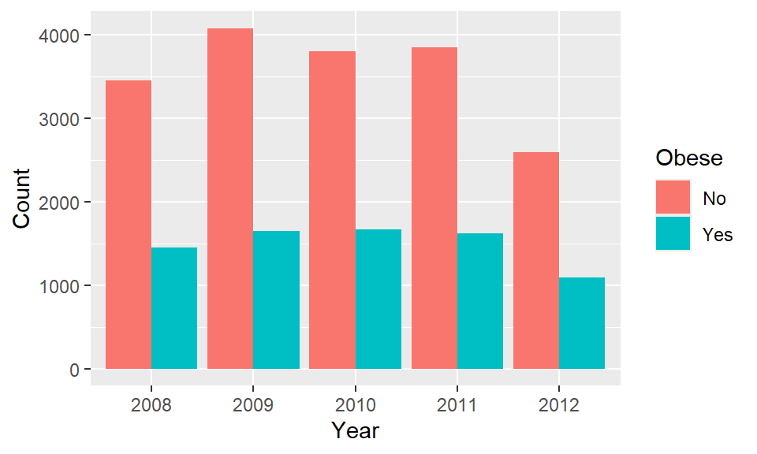

Figure 2: Count of Obesity Classification by Year

We can observe that in each year, the “No” bar (non-obese) is taller than the “Yes” bar (obese). However, the gap between these two bars may differ slightly from year to year.

# 3 Formal Analysis

The logistic regression model is given by:

$$\begin{align}
y_i &\sim \mathrm{Bernoulli}(p_i) \\
\end{align}$$
$$\begin{align}
logit(p_i) = \alpha + \beta_{year2009} \cdot \mathbb{I}_{\mathrm{year2009}} + \beta_{year2010} \cdot \mathbb{I}_{\mathrm{year2010}} + \beta_{year2011} \cdot \mathbb{I}_{\mathrm{year2011}} + \beta_{year2012} \cdot \mathbb{I}_{\mathrm{year2012}}
\end{align}$$

Logistic Regression Model Summary

| term | estimate | std.error | statistic | p.value |
| --- | --- | --- | --- | --- |
| (Intercept) | 0.420 | 0.031 | -27.716 | 4.43e-169 |
| Year2009 | 0.963 | 0.043 | -0.882 | 0.378 |
| Year2010 | 1.044 | 0.043 | 1.003 | 0.316 |
| Year2011 | 1.004 | 0.043 | 0.088 | 0.929 |
| Year2012 | 1.002 | 0.048 | 0.036 | 0.971 |

The fitted model is:
$$logit(p_i) = -0.867901 -0.037769 \cdot \mathbb{I}_{\mathrm{year2009}} + 0.043062 \cdot \mathbb{I}_{\mathrm{year2010}} + 0.003814 \cdot \mathbb{I}_{\mathrm{year2011}} + 0.001743 \cdot \mathbb{I}_{\mathrm{year2012}}$$
We have fitted a logistic regression model to observe the relation between the years and obesity prevalance in Scotland over the years 2008-2012.
The baseline category is taken to be Year 2008. From the output odds model summary, we can see that the odds of being obese in Year 2008 was 0.42.
The coefficients for Year2009, Year2010, Year2011, Year2012 represents the change in odds of being obese compared to the baseline year 2008.

Here are the odds plot of out logistic regression:

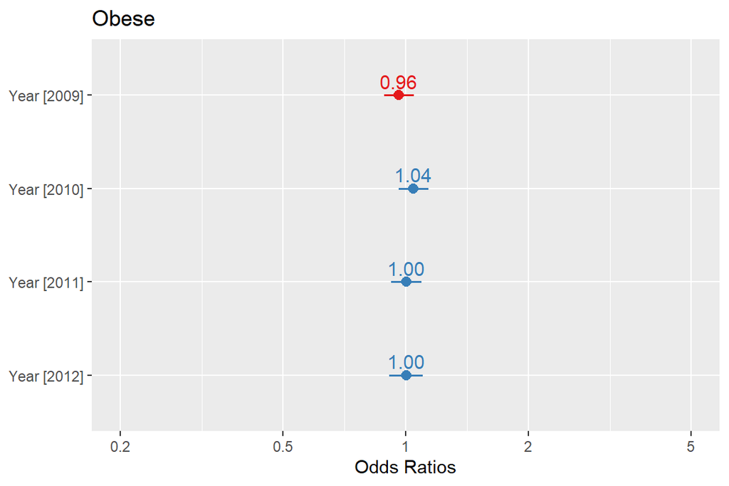

Figure 3: Odds (being obese compared to Year 2008)

We can observe from Figure 3 that:

The plotted values (0.96, 1.04, 1.00, and 1.00) are all very close to 1. This suggests that, compared to the reference year, the odds of being obese in these specific years do not differ dramatically.  
Because the odds ratios are near 1, there is likely no strong evidence that obesity prevalence changed significantly across these years. Any differences (e.g., 0.96 vs. 1.04) are quite small and may not be statistically or practically meaningful.

# 4 Conclusions

The exploratory analysis, through line and bar plots, suggested that while obesity prevalence fluctuated across the years, there was no clear upward or downward trend. This observation was supported by the logistic regression analysis, which used 2008 as the baseline year. The model’s odds ratios for subsequent years (2009–2012) were all very close to 1 and none of the differences reached statistical significance.

Hence we can conclude that over the period studied (2008-2012) there was no evidence of a significant change in obesity prevalence in Scotland. Future studies should consider longer time frames and incorporate additional covariates to better capture potential trends and identify factors that might influence obesity rates more effectively.